# Log Transformation

Ty Painter

October 23, 2020

# 1 Introduction

In this blog post I will analyze the transformation of data among various distributions. I will use both analytic and simulation methods to examine the Cumulative Distribution Function (CDF) and the Probability Density Function (PDF) along with the geometric and arithmetic means.

## 1.1 Background

```r
library(tidyverse)
library(ggplot2)
require(magrittr)
```

## 1.2 Part 1

### 1.2.1 X~Gamma(shape = 3, scale = 1)

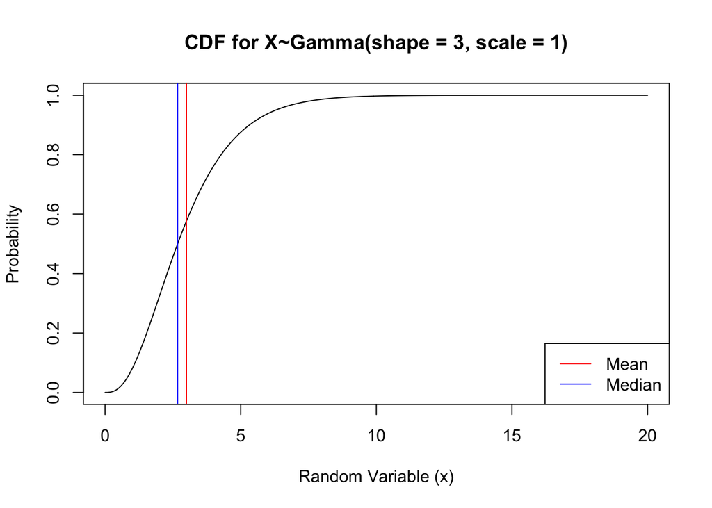

```r
shp = 3
scal = 1
gam_quant = seq(0,20, by=.1)
mean_gam = shp*scal # gamma mean
median_gam = qgamma(.5,shp,scal) # gamma median

# Graph 1
gam_cdf <- function(x) pgamma(x, shape = shp, scale = scal) # gamma CDF function
plot(gam_quant, gam_cdf(gam_quant), type = 'l', # CDF
      xlab = "Random Variable (x)",
      ylab = "Probability",
      main = "CDF for X~Gamma(shape = 3, scale = 1)")
      abline(v=mean_gam, col = 'red')
      abline(v=median_gam, col = 'blue')
      legend("bottomright", c("Mean", "Median"), col=c("red", "blue"), lty=1)
```

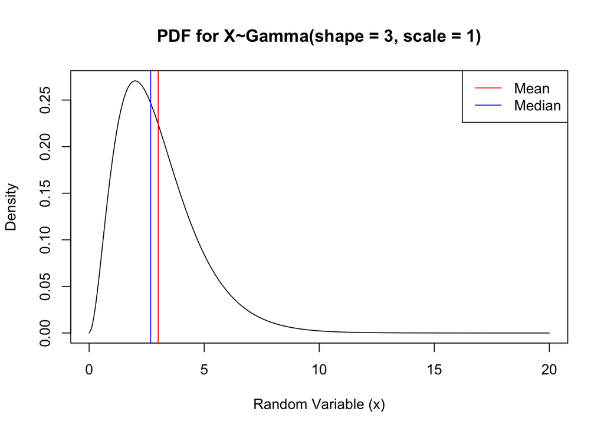

```r
gam_pdf <- function(x) dgamma(x, shape = shp, scale = scal) # gamma PDF function
plot(gam_quant, gam_pdf(gam_quant), type = 'l', # PDF
      xlab = "Random Variable (x)",
      ylab = "Density",
      main = "PDF for X~Gamma(shape = 3, scale = 1)")
      abline(v=mean_gam, col = 'red')
      abline(v=median_gam, col = 'blue')
      legend("topright", c("Mean", "Median"), col=c("red", "blue"), lty=1)
```

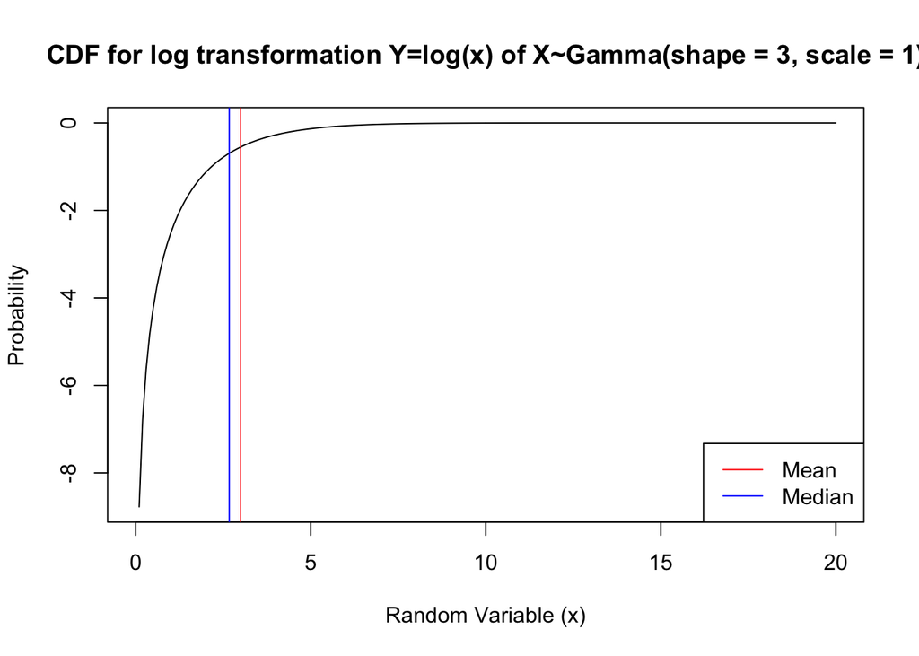

```r
# Graph 2
plot(gam_quant, log(gam_cdf(gam_quant)), type = 'l', # CDF log transformation
      xlab = "Random Variable (x)",
      ylab = "Probability",
      main = "CDF for log transformation Y=log(x) of X~Gamma(shape = 3, scale = 1)")
      abline(v=mean_gam, col = 'red')
      abline(v=median_gam, col = 'blue')
      legend("bottomright", c("Mean", "Median"), col=c("red", "blue"), lty=1)
```

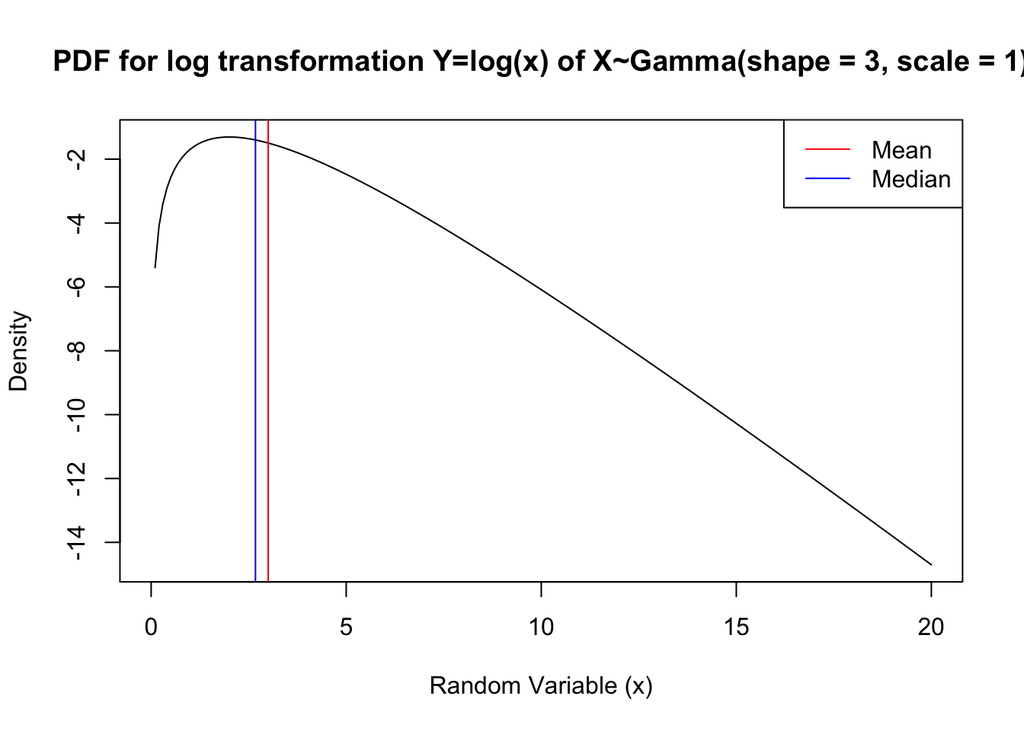

```r
plot(gam_quant, log(gam_pdf(gam_quant)), type = 'l', # PDF log transformation
      xlab = "Random Variable (x)",
      ylab = "Density",
      main = "PDF for log transformation Y=log(x) of X~Gamma(shape = 3, scale = 1)")
      abline(v=mean_gam, col = 'red')
      abline(v=median_gam, col = 'blue')
      legend("topright", c("Mean", "Median"), col=c("red", "blue"), lty=1)
```

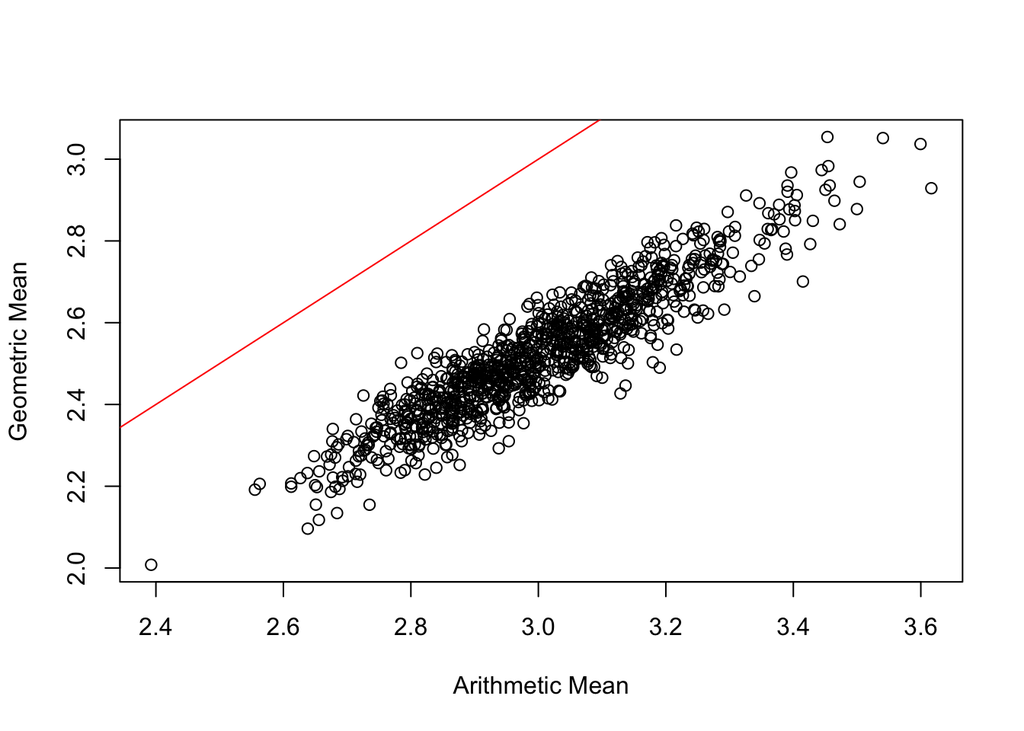

```r
# Graph 3
samp <- 1000
sz <- 100
set.seed(10202020)
D1 <- rgamma(samp*sz, shape = 3, scale = 1) %>% # create an array of 1,000 samples of size 100
  array(dim = c(samp,sz))
gam_am <- apply(D1, 1, function(x) {mean(x)}) # arithmetic mean of each row
gam_gm <- apply(D1, 1, function(x) {exp(mean(log(x)))}) # geometric mean of each row
plot(gam_am, gam_gm,
     xlab = "Arithmetic Mean",
     ylab = "Geometric Mean")
abline(0,1, col = "red")
```

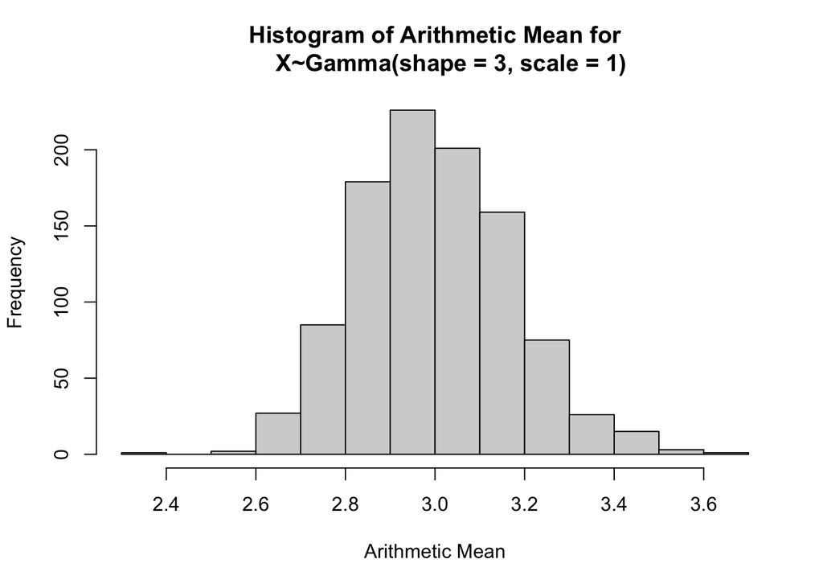

```r
# Histograms
hist(gam_am,
     xlab = "Arithmetic Mean",
     main = "Histogram of Arithmetic Mean for
     X~Gamma(shape = 3, scale = 1)")
```

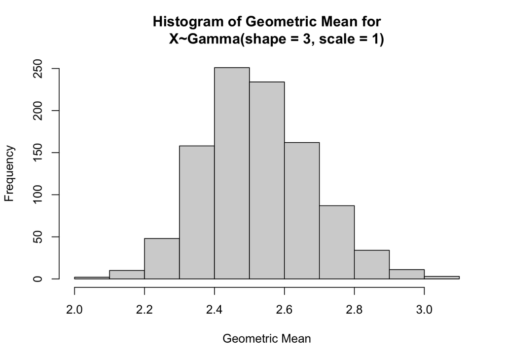

```r
hist(gam_gm,
     xlab = "Geometric Mean",
     main = "Histogram of Geometric Mean for
     X~Gamma(shape = 3, scale = 1)")
```

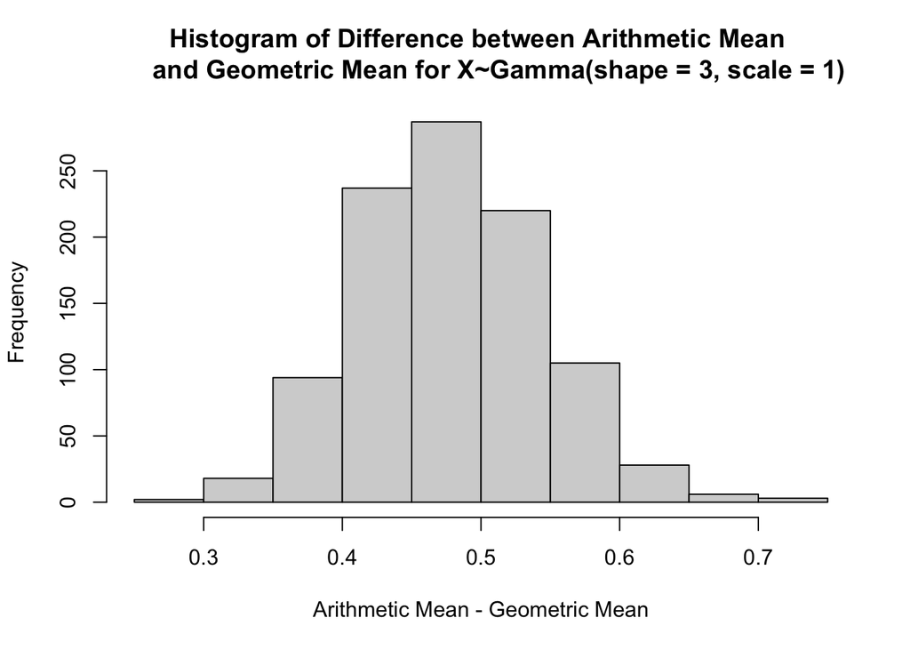

```r
hist(gam_am - gam_gm,
     xlab = "Arithmetic Mean - Geometric Mean",
     main = "Histogram of Difference between Arithmetic Mean
     and Geometric Mean for X~Gamma(shape = 3, scale = 1)")
```

### 1.2.2 X∼LOG NORMAL(μ = −1, σ = 1)

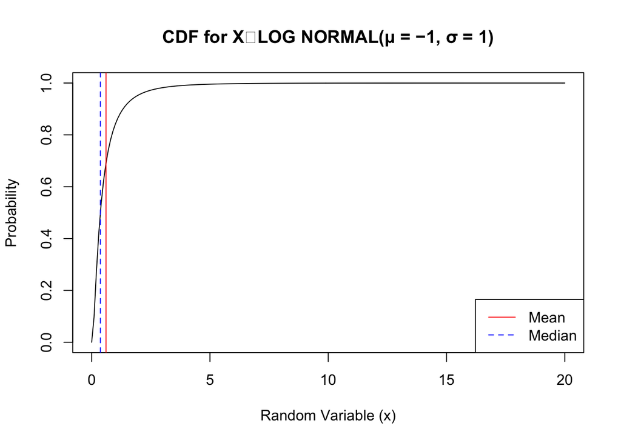

```r
mu = -1
sig = 1
mean_norm = exp(mu+(sig^2/2)) # mean
median_norm = exp(mu) # median
norm_quant = seq(0,20,.1)

# Graph 1
norm_cdf <- function(x) plnorm(x,mu,sig) # normal CDF function
plot(norm_quant, norm_cdf(norm_quant), type = 'l', # CDF
      xlab = "Random Variable (x)",
      ylab = "Probability",
      main = "CDF for X∼LOG NORMAL(μ = −1, σ = 1)")
      abline(v=mean_norm, col = 'red')
      abline(v=median_norm, col = 'blue', lty=2)
      legend("bottomright", c("Mean", "Median"), col=c("red", "blue"), lty=c(1,2))
```

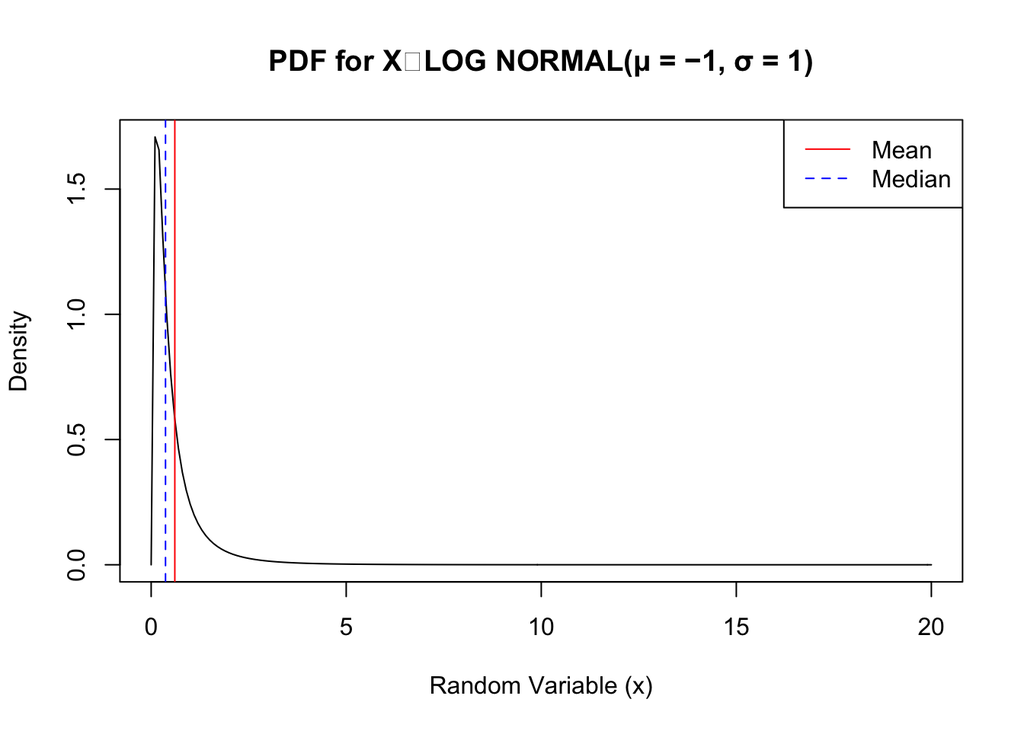

```r
norm_pdf <- function(x) dlnorm(x,mu,sig) # normal PDF function
plot(norm_quant, norm_pdf(norm_quant), type = 'l', # PDF
      xlab = "Random Variable (x)",
      ylab = "Density",
      main = "PDF for X∼LOG NORMAL(μ = −1, σ = 1)")
      abline(v=mean_norm, col = 'red')
      abline(v=median_norm, col = 'blue', lty=2)
      legend("topright", c("Mean", "Median"), col=c("red", "blue"), lty=c(1,2))
```

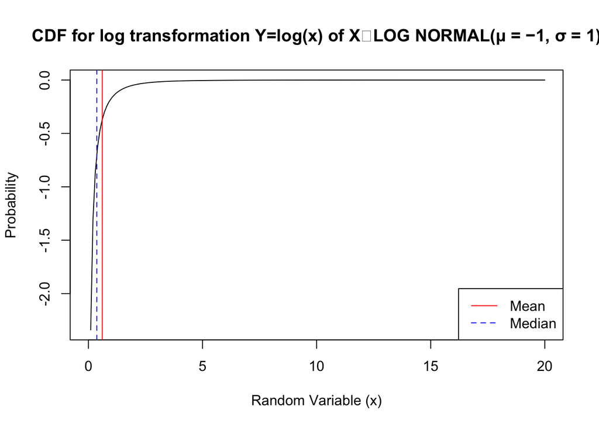

```r
# Graph 2
plot(norm_quant, log(norm_cdf(norm_quant)), type = 'l', # CDF log transformation
      xlab = "Random Variable (x)",
      ylab = "Probability",
      main = "CDF for log transformation Y=log(x) of X∼LOG NORMAL(μ = −1, σ = 1)")
      abline(v=mean_norm, col = 'red')
      abline(v=median_norm, col = 'blue', lty=2)
      legend("bottomright", c("Mean", "Median"), col=c("red", "blue"), lty=c(1,2))
```

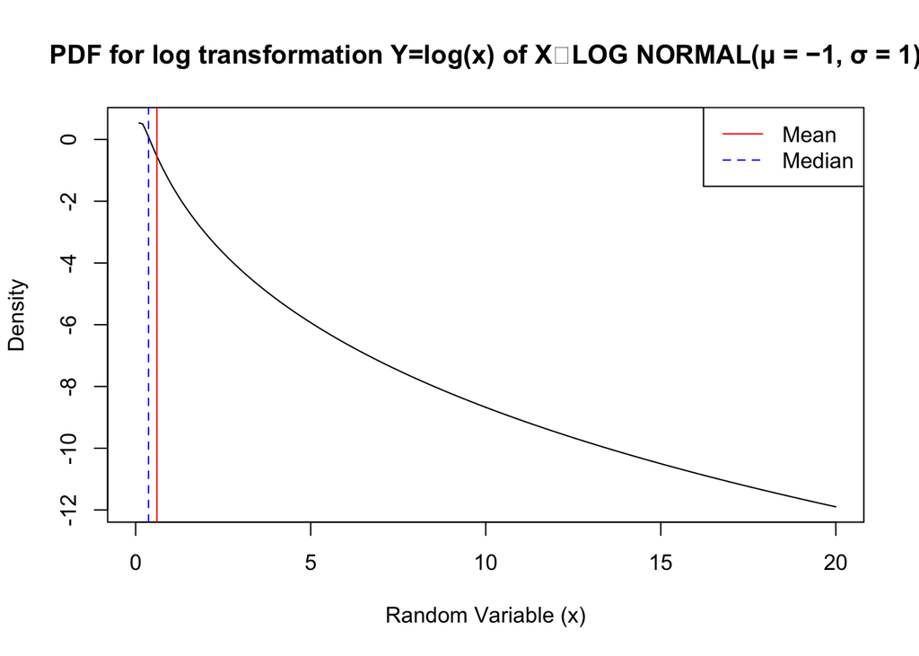

```r
plot(norm_quant, log(norm_pdf(norm_quant)), type = 'l', # PDF log transformation
      xlab = "Random Variable (x)",
      ylab = "Density",
      main = "PDF for log transformation Y=log(x) of X∼LOG NORMAL(μ = −1, σ = 1)")
      abline(v=mean_norm, col = 'red')
      abline(v=median_norm, col = 'blue', lty=2)
      legend("topright", c("Mean", "Median"), col=c("red", "blue"), lty=c(1,2))
```

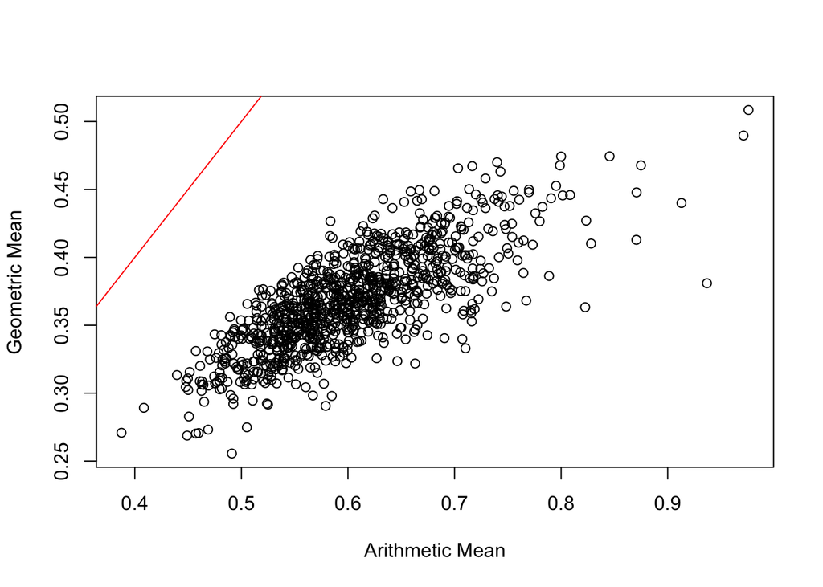

```r
# Graph 3
D2 <- rlnorm(samp*sz,mu,sig) %>% # create an array of 1,000 samples of size 100
  array(dim = c(samp,sz))
norm_am <- apply(D2, 1, function(x) {mean(x)}) # arithmetic mean of each row
norm_gm <- apply(D2, 1, function(x) {exp(mean(log(abs(x))))}) # geometric mean of each row !!! LOG - # !!!
plot(norm_am, norm_gm,
     xlab = "Arithmetic Mean",
     ylab = "Geometric Mean")
abline(0,1, col = "red")
```

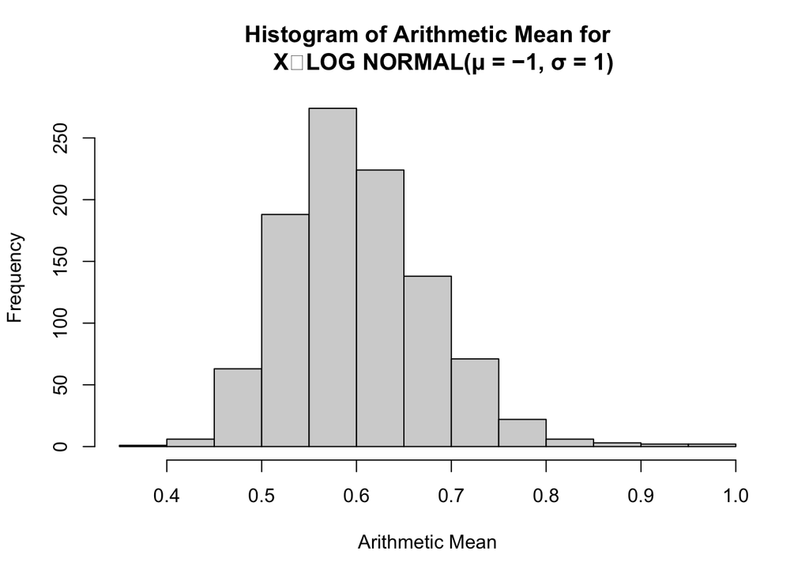

```r
# Histograms
hist(norm_am,
     xlab = "Arithmetic Mean",
     main = "Histogram of Arithmetic Mean for
     X∼LOG NORMAL(μ = −1, σ = 1)")
```

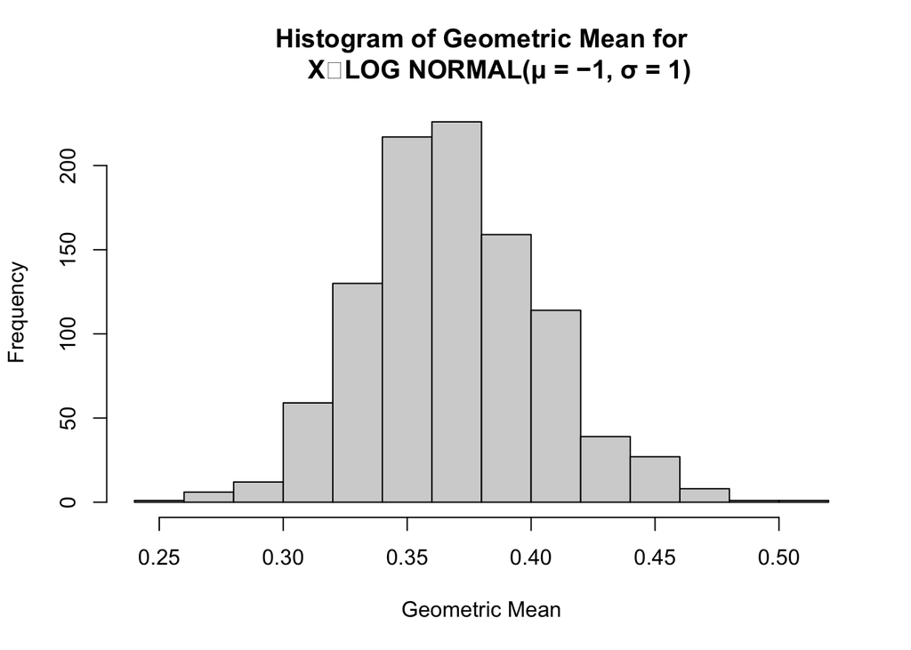

```r
hist(norm_gm,
     xlab = "Geometric Mean",
     main = "Histogram of Geometric Mean for
     X∼LOG NORMAL(μ = −1, σ = 1)")
```

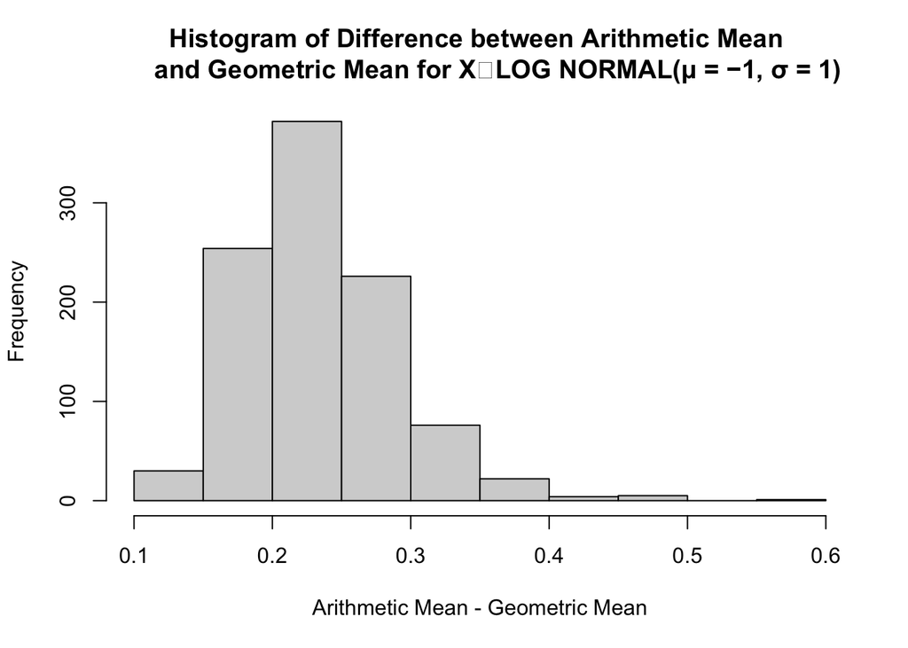

```r
hist(norm_am - norm_gm,
     xlab = "Arithmetic Mean - Geometric Mean",
     main = "Histogram of Difference between Arithmetic Mean
     and Geometric Mean for X∼LOG NORMAL(μ = −1, σ = 1)")
```

### 1.2.3 X~UNIFORM(0, 12)

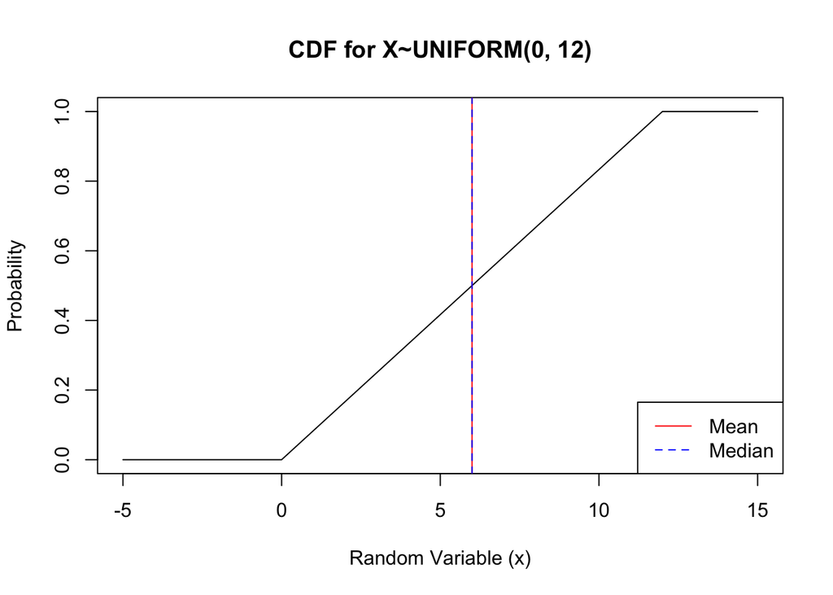

```r
min_unif = 0 # min
max_unif = 12 # max
median_unif = 1/2 * (0+12) # median
mean_unif = 1/2 * (0+12)
unif_quant = seq(-5,15,.1)

# Graph 1
unif_cdf <- function(x) punif(x, min_unif, max_unif) # uniform CDF function
plot(unif_quant, unif_cdf(unif_quant), type = 'l', # CDF
      xlab = "Random Variable (x)",
      ylab = "Probability",
      main = "CDF for X~UNIFORM(0, 12)")
      abline(v=mean_unif, col = 'red')
      abline(v=median_unif, col = 'blue', lty=2)
      legend("bottomright", c("Mean", "Median"), col=c("red", "blue"), lty=c(1,2))
```

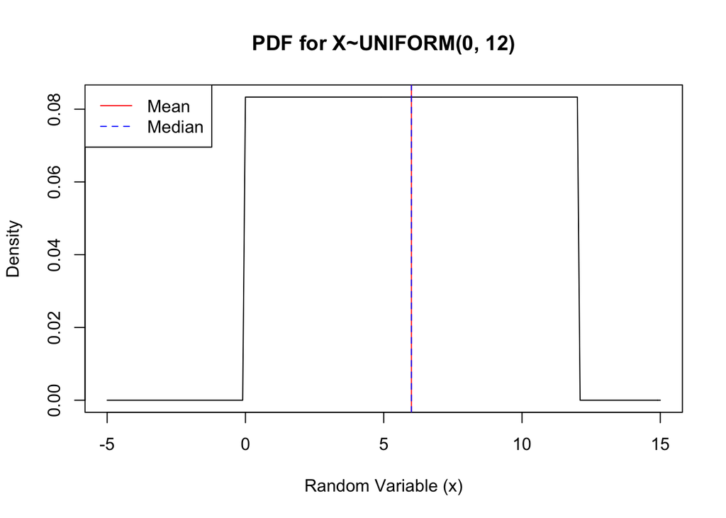

```r
unif_pdf <- function(x) dunif(x, min_unif, max_unif) # uniform PDF function
plot(unif_quant, unif_pdf(unif_quant), type = 'l', # PDF
      xlab = "Random Variable (x)",
      ylab = "Density",
      main = "PDF for X~UNIFORM(0, 12)")
      abline(v=mean_unif, col = 'red')
      abline(v=median_unif, col = 'blue', lty=2)
      legend("topleft", c("Mean", "Median"), col=c("red", "blue"), lty=c(1,2))
```

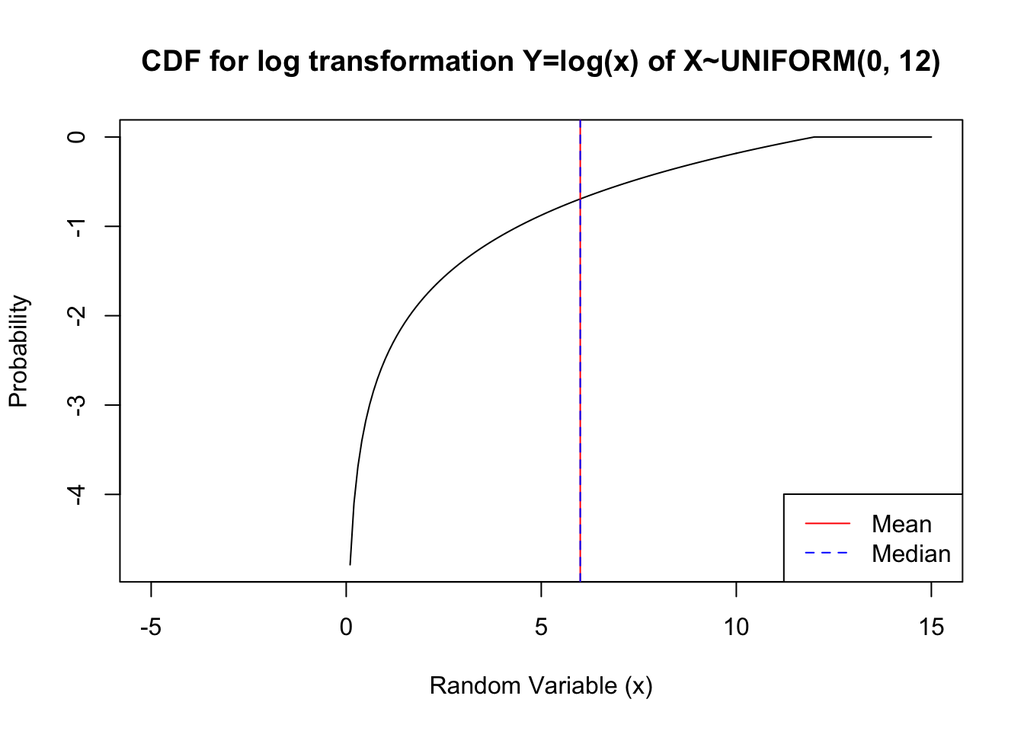

```r
# Graph 2
plot(unif_quant, log(unif_cdf(unif_quant)), type = 'l', # CDF log transformation
      xlab = "Random Variable (x)",
      ylab = "Probability",
      main = "CDF for log transformation Y=log(x) of X~UNIFORM(0, 12)")
      abline(v=mean_unif, col = 'red')
      abline(v=median_unif, col = 'blue', lty=2)
      legend("bottomright", c("Mean", "Median"), col=c("red", "blue"), lty=c(1,2))
```

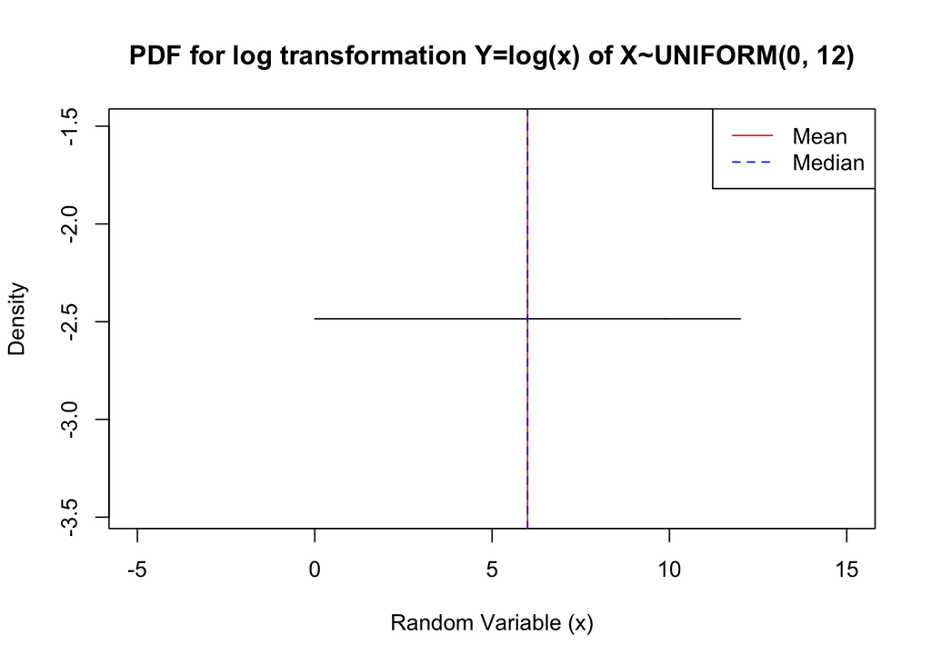

```r
plot(unif_quant, log(unif_pdf(unif_quant)), type = 'l', # PDF log transformation
      xlab = "Random Variable (x)",
      ylab = "Density",
      main = "PDF for log transformation Y=log(x) of X~UNIFORM(0, 12)")
      abline(v=mean_unif, col = 'red')
      abline(v=median_unif, col = 'blue', lty=2)
      legend("topright", c("Mean", "Median"), col=c("red", "blue"), lty=c(1,2))
```

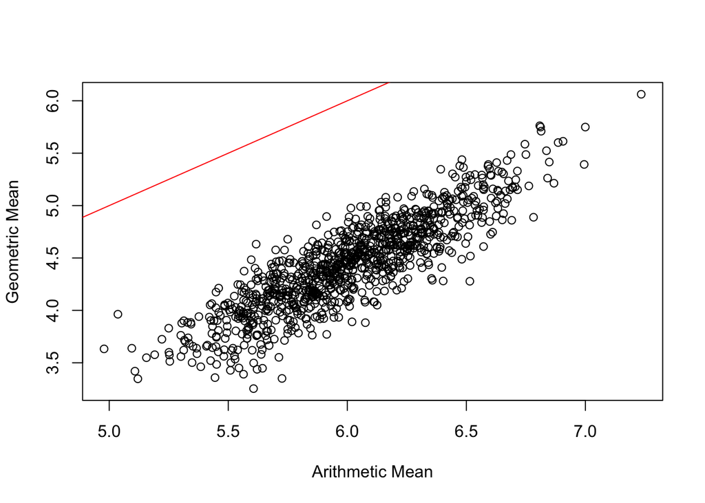

```r
# Graph 3
D3 <- runif(samp*sz, min_unif, max_unif) %>% # create an array of 1,000 samples of size 100
  array(dim = c(samp,sz))
unif_am <- apply(D3, 1, function(x) {mean(x)}) # arithmetic mean of each row
unif_gm <- apply(D3, 1, function(x) {exp(mean(log(x)))}) # geometric mean of each row
plot(unif_am, unif_gm,
     xlab = "Arithmetic Mean",
     ylab = "Geometric Mean")
abline(0,1, col = "red")
```

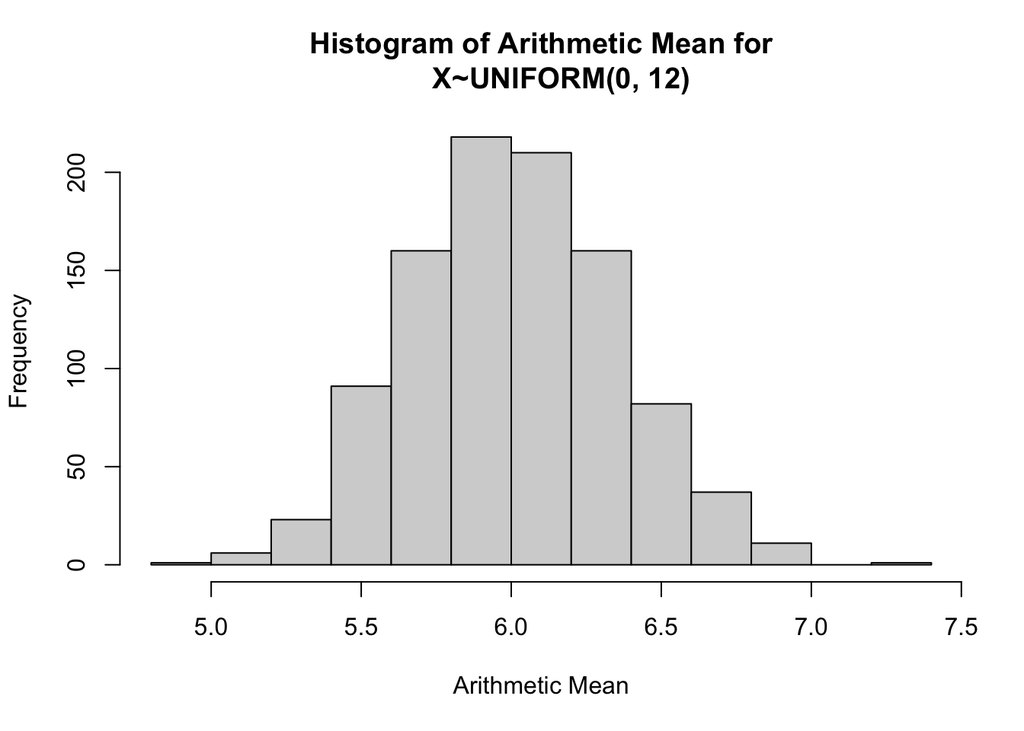

```r
# Histograms
hist(unif_am,
     xlab = "Arithmetic Mean",
     main = "Histogram of Arithmetic Mean for
     X~UNIFORM(0, 12)")
```

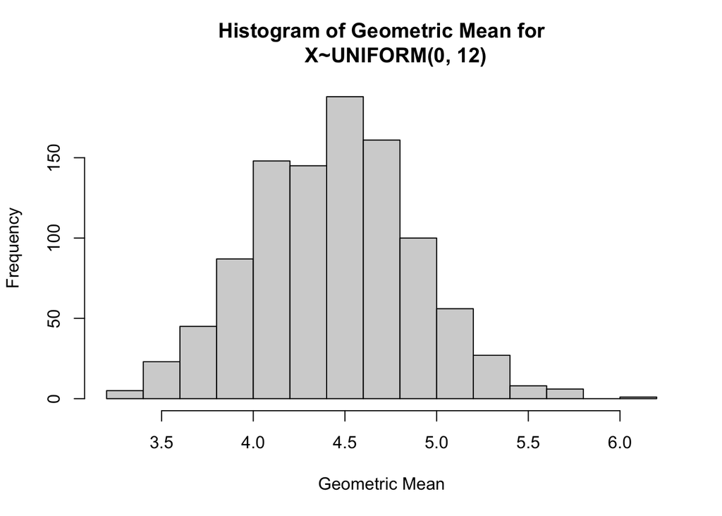

```r
hist(unif_gm,
     xlab = "Geometric Mean",
     main = "Histogram of Geometric Mean for
     X~UNIFORM(0, 12)")
```

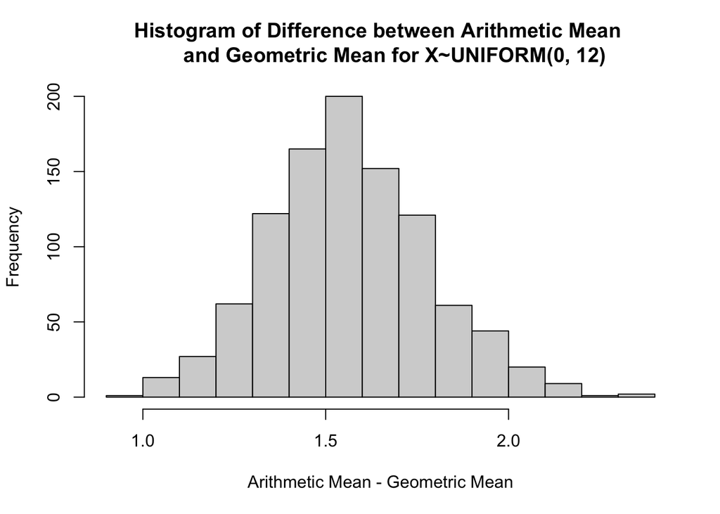

```r
hist(unif_am - unif_gm,
     xlab = "Arithmetic Mean - Geometric Mean",
     main = "Histogram of Difference between Arithmetic Mean
     and Geometric Mean for X~UNIFORM(0, 12)")
```

In the uniform function all values within the minimum, 0, and maximum, 12, have the same relative likelihood (density) of being selected resulting in a flat, horizontal line on the PDF. On the CDF, the minimum value is equal to 0 and the maximum value is equal to 1 since all values in the distribution are equal to or less than the maximum value of 12. Once again the arithmetic means are larger than the geometric means. The arithmetic means are popular around 6, while the geometric means populate around 4.5.

## 1.3 Part 2

Show that if *X*<sub>*i*</sub> > 0 for all *i*, then the arithmetic mean is greater than or equal to the geometric mean.

Hint: Start with the sample mean of the transformation *Y*<sub>*i*</sub> = log (*X*<sub>*i*</sub>).

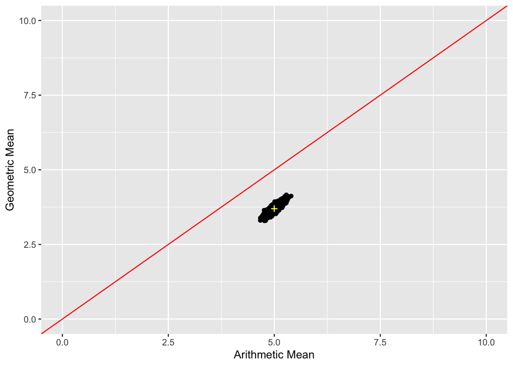

```r
samp = 1000
sim = 10000
set.seed((102120))
data <- runif(samp*sim, 0.01, 10) %>% # create an array of 1,000 samples of size 100
  array(dim = c(sim,samp))
am <- apply(data, 1, function(x) {mean(x)}) # arithmetic mean of each row
gm <- apply(data, 1, function(x) {exp(mean(log(x)))}) # geometric mean of each row

df <- data.frame(Arithmetic_Mean = am, Geometric_Mean = gm)

ggplot(df) +
  geom_point(aes(x=am, y=gm)) +
  geom_point(x=5, y= 3.7, shape=3, col = "yellow") +
  geom_abline(slope = 1, col = "red") +
  xlim(0,10) +
  ylim(0,10) +
  labs(
    x = "Arithmetic Mean",
    y = "Geometric Mean"
  )
```

To show that the arithmetic mean is always greater than the geometric mean, I ran 10,000 simulations with 1,000 samples each over a uniform distribution and calculated both the geometric and arithmetic means for each simulation. The red line above intercepts at (0,0) and has a slope of 1. This means that the x and y values are equal along the line. Anything above the line favors the y-value, and ything below the line favors the x-value. You can see that every point forms a cluster around (5,3.7) implying the x-value is larger. Another indicator is that every point falls below the red line concluding that the x-value, arithmetic mean, is larger than the y-value, geometric mean.

This can also be explained by using *Y*<sub>*i*</sub> = log (*X*<sub>*i*</sub>). Log transformations are done to compare data on a relative scale. Because of this the data is adjusted for skewness and will be reduced so that it is never bigger than the arithmetic mean, which is on an absolute scale.

## 1.4 Part 3

What is the correct relationship between *E*[log (*X*)] and log (*E*[*X*])? Is one always larger? Equal? Explain your answer.

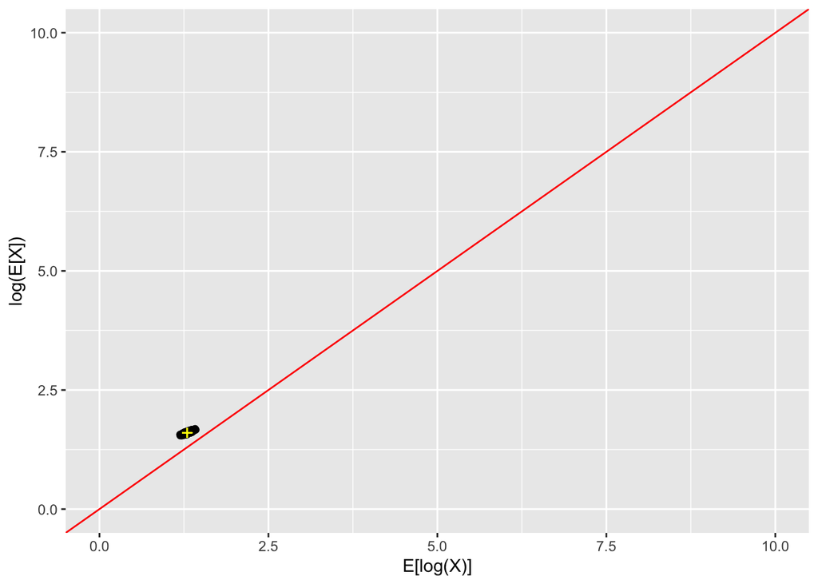

```r
before <- apply(data, 1, function(x) {mean(log(x))}) # arithmetic mean of each row
after <- apply(data, 1, function(x) {log(mean(x))}) # geometric mean of each row

df2 <- data.frame(before = before, after = after)
ggplot(df2) +
  geom_point(aes(x=before, y=after)) +
  geom_point(x=1.3, y= 1.6, shape=3, col = "yellow") +
  geom_abline(slope = 1, col = "red") +
  xlim(0,10) +
  ylim(0,10) +
  labs(
    x = "E[log(X)]",
    y = "log(E[X])"
  )
```

The *E*[*X*] is also known as the average value of X. I used the same process and logic from Part 2 to display the results. All of the dots appear above the line of identify implying the *log(E[X])* value is larger. This is also explained by *Jensen’s Inequality* which states “the convex transformation of a mean is less than or equal to the mean applied after convex transformation.” Although my graph did not display any points that were equal, or on the red line, I believe it accurately depicts Jensen’s Inequality.

# 2 Conclusion